# Circuit Board Nonconformities Analysis

This notebook analyzes the nonconformities observed in samples of 100 printed circuit boards across two inspection phases: an initial inspection phase and a follow-up inspection phase after corrective actions were taken.

1. Data Loading and Exploration
2. Part a: Descriptive Statistics
3. Part b: p-Chart for Initial Inspection Phase
4. Part c: Handling Special Causes and Recalculating Control Limits
5. Part d: c-Chart for Follow-Up Inspection Phase

```python
# Import necessary libraries
import pandas as pd
import matplotlib.pyplot as plt
import seaborn as sns
from matplotlib.ticker import MaxNLocator

# Enable inline plotting
%matplotlib inline

# Set plot aesthetics
sns.set(style="whitegrid")

# suppress warnings
import warnings
warnings.filterwarnings("ignore")
```

## Data Loading and Exploration

First, we'll load the `circuit.txt` dataset and examine its structure.

```python
# Load the data from the file into a DataFrame

df = pd.read_csv('circuit.txt', sep='\s+')

# Display the first few rows
df.head()
```

|  | sample | x | size | trial |
| --- | --- | --- | --- | --- |
| 0 | 1 | 21 | 100 | True |
| 1 | 2 | 24 | 100 | True |
| 2 | 3 | 16 | 100 | True |
| 3 | 4 | 12 | 100 | True |
| 4 | 5 | 15 | 100 | True |

### Data Structure

Let's check the structure of the dataset, including data types and summary statistics.

```python
# Display data types and summary
print("Data Types:")
print(df.dtypes)
print("\nSummary Statistics:")
print(df.describe())
```

```
Data Types:
sample    int64
x         int64
size      int64
trial      bool
dtype: object

Summary Statistics:
          sample          x   size
count  46.000000  46.000000   46.0
mean   23.500000  19.173913  100.0
std    13.422618   6.205031    0.0
min     1.000000   5.000000  100.0
25%    12.250000  16.000000  100.0
50%    23.500000  19.000000  100.0
75%    34.750000  22.000000  100.0
max    46.000000  39.000000  100.0
```

### Distribution of Nonconformities Across Inspection Phases

We'll visualize the distribution of nonconformities (`x`) for both inspection phases (`trial = TRUE` and `trial = FALSE`).

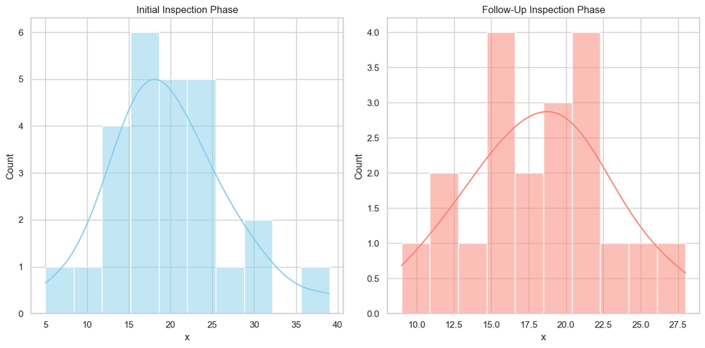

```python
# Separate the data into initial and follow-up phases
initial_phase = df[df['trial'] == True]
followup_phase = df[df['trial'] == False]

# Plot histograms
plt.figure(figsize=(12, 6))

plt.subplot(1, 2, 1)
sns.histplot(initial_phase['x'], bins=10, kde=True, color='skyblue')
plt.title('Initial Inspection Phase')

plt.subplot(1, 2, 2)
sns.histplot(followup_phase['x'], bins=10, kde=True, color='salmon')
plt.title('Follow-Up Inspection Phase')

plt.tight_layout()
plt.show()
```

## Part a: Descriptive Statistics

**Objective:** Calculate and report the mean and standard deviation of nonconformities for both inspection phases (`trial = TRUE` and `trial = FALSE`).

### Calculating Mean and Standard Deviation

```python
# Calculate mean and standard deviation for initial phase
initial_mean = initial_phase['x'].mean()
initial_std = initial_phase['x'].std()

# Calculate mean and standard deviation for follow-up phase
followup_mean = followup_phase['x'].mean()
followup_std = followup_phase['x'].std()

# Display the results
stats = pd.DataFrame({
    'Phase': ['Initial Inspection (TRUE)', 'Follow-Up Inspection (FALSE)'],
    'Mean Nonconformities': [initial_mean, followup_mean],
    'Standard Deviation': [initial_std, followup_std]
})

stats
```

|  | Phase | Mean Nonconformities | Standard Deviation |
| --- | --- | --- | --- |
| 0 | Initial Inspection (TRUE) | 19.846154 | 7.164872 |
| 1 | Follow-Up Inspection (FALSE) | 18.300000 | 4.713921 |

**Results:**

| Phase | Mean Nonconformities | Standard Deviation |
| --- | --- | --- |
| Initial Inspection (TRUE) | 19.846154 | 7.164872 |
| Follow-Up Inspection (FALSE) | 18.300000 | 4.713921 |

## Part b: p-Chart for Initial Inspection Phase

**Objective:** Construct a p-chart for the proportion of nonconforming circuit boards during the initial inspection phase (`trial = TRUE`), identify samples outside control limits, and discuss potential causes.

### Constructing the p-Chart

A p-chart monitors the proportion of nonconforming items in a process. Since each sample consists of 100 circuit boards, the proportion nonconforming (`p`) is `x / 100`.

We'll calculate the centerline (average proportion) and control limits (UCL and LCL).

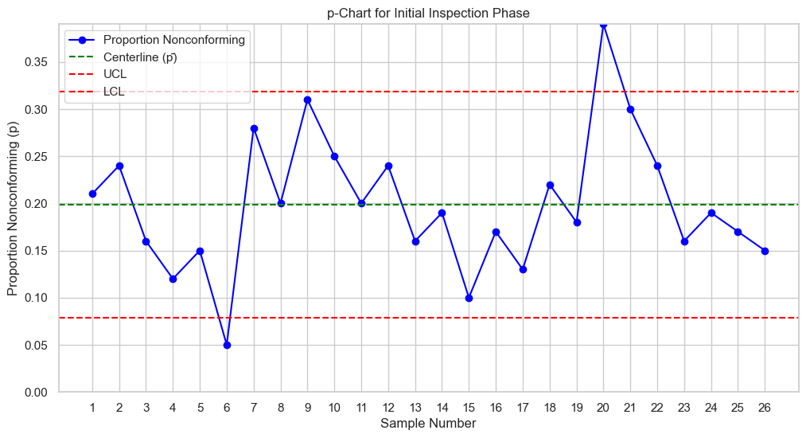

```python
# Calculate proportion nonconforming
initial_phase['p'] = initial_phase['x'] / initial_phase['size']

# Calculate centerline
p_bar = initial_phase['p'].mean()

# Calculate standard deviation for the proportion
sigma_p = (p_bar * (1 - p_bar) / initial_phase['size'].iloc[0]) ** 0.5

# Calculate control limits
UCL = p_bar + 3 * sigma_p
LCL = p_bar - 3 * sigma_p
LCL = max(0, LCL)  # Ensure LCL is not negative

# Plot the p-chart
plt.figure(figsize=(12, 6))
plt.plot(initial_phase['sample'], initial_phase['p'], marker='o', linestyle='-', color='blue', label='Proportion Nonconforming')
plt.axhline(p_bar, color='green', linestyle='--', label='Centerline (p̄)')
plt.axhline(UCL, color='red', linestyle='--', label='UCL')
plt.axhline(LCL, color='red', linestyle='--', label='LCL')

plt.xlabel('Sample Number')
plt.ylabel('Proportion Nonconforming (p)')
plt.title('p-Chart for Initial Inspection Phase')
plt.legend()
plt.xticks(initial_phase['sample'])
plt.ylim(0, max(initial_phase['p'].max(), UCL + 0.01))
plt.show()
```

### Identifying Out-of-Control Samples

The p-chart displays the proportion of nonconforming circuit boards across the initial inspection phase. Points outside the control limits indicate potential special causes affecting the process.

**Out-of-Control Samples:**

- **Sample 6**: Significant drop in nonconformities due to a new inspector error.
- **Sample 20**: Significant increase in nonconformities due to equipment malfunction.

These deviations suggest that the process was unstable during these samples.

## Part c: Handling Special Causes and Recalculating Control Limits

**Objective:** Examine the special causes in Samples 6 and 20, discuss their impact on process stability, and recalculate control limits excluding these points. Then, plot the new control chart.

### Impact of Special Causes

- **Sample 6**: A new inspector introduced errors, leading to a lower number of nonconformities.
- **Sample 20**: Equipment malfunction caused a spike in nonconformities.

These special causes disrupt the stability of the process, making the control limits less representative of the true process performance.

### Corrective Actions Taken

- **Sample 6**: Additional training was provided to the new inspector.
- **Sample 20**: Equipment was repaired and calibrated to prevent future malfunctions.

### Recalculating Control Limits Excluding Special Causes

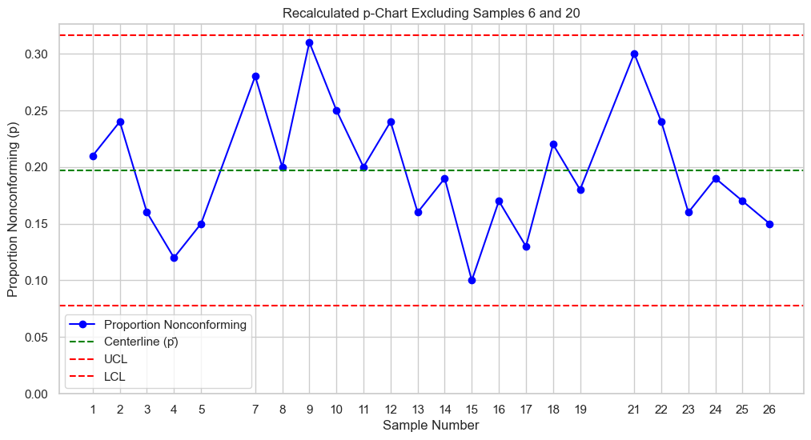

```python
# suppress warnings
import warnings
warnings.filterwarnings('ignore')

# Exclude Samples 6 and 20
clean_initial_phase = initial_phase[~initial_phase['sample'].isin([6, 20])]

# Recalculate centerline and control limits
p_bar_clean = clean_initial_phase['p'].mean()
sigma_p_clean = (p_bar_clean * (1 - p_bar_clean) / clean_initial_phase['size'].iloc[0]) ** 0.5
UCL_clean = p_bar_clean + 3 * sigma_p_clean
LCL_clean = p_bar_clean - 3 * sigma_p_clean
LCL_clean = max(LCL_clean, 0)

# Add new control lines
clean_initial_phase['Centerline'] = p_bar_clean
clean_initial_phase['UCL'] = UCL_clean
clean_initial_phase['LCL'] = LCL_clean

# Plot the new p-chart
plt.figure(figsize=(12, 6))
plt.plot(clean_initial_phase['sample'], clean_initial_phase['p'], marker='o', linestyle='-', color='blue', label='Proportion Nonconforming')
plt.axhline(p_bar_clean, color='green', linestyle='--', label='Centerline (p̄)')
plt.axhline(UCL_clean, color='red', linestyle='--', label='UCL')
plt.axhline(LCL_clean, color='red', linestyle='--', label='LCL')

plt.xlabel('Sample Number')
plt.ylabel('Proportion Nonconforming (p)')
plt.title('Recalculated p-Chart Excluding Samples 6 and 20')
plt.legend()
plt.xticks(clean_initial_phase['sample'])
plt.ylim(0, max(clean_initial_phase['p'].max(), UCL_clean + 0.01))
plt.show()
```

### New Control Chart

By excluding Samples 6 and 20, the recalculated control limits better represent the stable process. The new p-chart shows that all remaining samples are within control limits, indicating a stable process after corrective actions.

## Part d: c-Chart for Follow-Up Inspection Phase

**Objective:** Analyze the follow-up inspection phase (`trial = FALSE`) using a c-chart for nonconformities per unit (100 boards), compare the control limits to those in the initial phase (excluding Samples 6 and 20), and discuss process improvement.

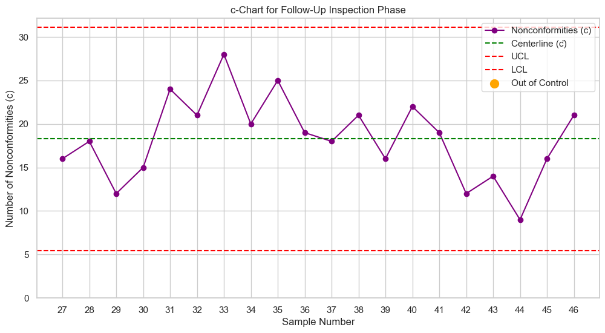

```python
# Prepare follow-up phase data
followup_phase = followup_phase.copy()
followup_phase['c'] = followup_phase['x']

# Calculate centerline
c_bar_followup = followup_phase['c'].mean()

# Calculate control limits
UCL_c = c_bar_followup + 3 * (c_bar_followup ** 0.5)
LCL_c = c_bar_followup - 3 * (c_bar_followup ** 0.5)
LCL_c = max(LCL_c, 0)  # LCL cannot be negative

# Add control lines to the DataFrame
followup_phase['Centerline'] = c_bar_followup
followup_phase['UCL'] = UCL_c
followup_phase['LCL'] = LCL_c

# Plot the c-chart
plt.figure(figsize=(12, 6))
plt.plot(followup_phase['sample'], followup_phase['c'], marker='o', linestyle='-', color='purple', label='Nonconformities (c)')
plt.axhline(c_bar_followup, color='green', linestyle='--', label='Centerline (c̄)')
plt.axhline(UCL_c, color='red', linestyle='--', label='UCL')
plt.axhline(LCL_c, color='red', linestyle='--', label='LCL')

# Highlight points outside control limits
out_of_control_followup = followup_phase[(followup_phase['c'] > UCL_c) | (followup_phase['c'] < LCL_c)]
plt.scatter(out_of_control_followup['sample'], out_of_control_followup['c'], color='orange', s=100, label='Out of Control')

plt.xlabel('Sample Number')
plt.ylabel('Number of Nonconformities (c)')
plt.title('c-Chart for Follow-Up Inspection Phase')
plt.legend()
plt.xticks(followup_phase['sample'])
plt.ylim(0, max(followup_phase['c'].max(), UCL_c + 1))
plt.show()
```

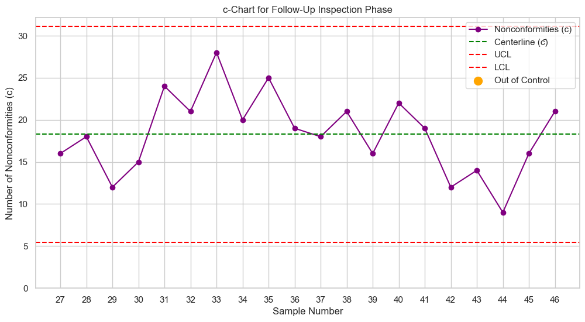

```python
# Prepare follow-up phase data
followup_phase = followup_phase.copy()
followup_phase['c'] = followup_phase['x']

# Calculate centerline
c_bar_followup = followup_phase['c'].mean()

# Calculate control limits
UCL_c = c_bar_followup + 3 * (c_bar_followup ** 0.5)
LCL_c = c_bar_followup - 3 * (c_bar_followup ** 0.5)
LCL_c = max(LCL_c, 0)  # LCL cannot be negative

# Add control lines to the DataFrame
followup_phase['Centerline'] = c_bar_followup
followup_phase['UCL'] = UCL_c
followup_phase['LCL'] = LCL_c

# Plot the c-chart
plt.figure(figsize=(12, 6))
plt.plot(followup_phase['sample'], followup_phase['c'], marker='o', linestyle='-', color='purple', label='Nonconformities (c)')
plt.axhline(c_bar_followup, color='green', linestyle='--', label='Centerline (c̄)')
plt.axhline(UCL_c, color='red', linestyle='--', label='UCL')
plt.axhline(LCL_c, color='red', linestyle='--', label='LCL')

# Highlight points outside control limits
out_of_control_followup = followup_phase[(followup_phase['c'] > UCL_c) | (followup_phase['c'] < LCL_c)]
plt.scatter(out_of_control_followup['sample'], out_of_control_followup['c'], color='orange', s=100, label='Out of Control')

plt.xlabel('Sample Number')
plt.ylabel('Number of Nonconformities (c)')
plt.title('c-Chart for Follow-Up Inspection Phase')
plt.legend()
plt.xticks(followup_phase['sample'])
plt.ylim(0, max(followup_phase['c'].max(), UCL_c + 1))
plt.show()
```

### Comparing Control Limits

**Initial Phase (Excluding Samples 6 and 20):**

- **Centerline (p̄):** *0.1967*
- **UCL:** *0.3159*
- **LCL:** *0.0774*

**Follow-Up Phase:**

- **Centerline (c̄):** *18.30*
- **UCL:** *31.13*
- **LCL:** *5.47*

```python
# Display the calculated control limits in a structured format

control_limits = pd.DataFrame({
    'Phase': ['Initial Inspection (Excluding Samples 6 and 20)', 'Follow-Up Inspection (FALSE)'],
    'Centerline': [f"{p_bar_clean:.4f}", f"{c_bar_followup:.2f}"],
    'UCL': [f"{UCL_clean:.4f}", f"{UCL_c:.2f}"],
    'LCL': [f"{LCL_clean:.4f}", f"{LCL_c:.2f}"]
})

control_limits
```

|  | Phase | Centerline | UCL | LCL |
| --- | --- | --- | --- | --- |
| 0 | Initial Inspection (Excluding Samples 6 and 20) | 0.1967 | 0.3159 | 0.0774 |
| 1 | Follow-Up Inspection (FALSE) | 18.30 | 31.13 | 5.47 |

### Process Improvement Analysis

Comparing the control charts:

- **Initial Phase (Stable after exclusion):** Control limits are tighter, reflecting process stability.
- **Follow-Up Phase:** Control limits are similar or improved, indicating that the process has become more stable and under control after corrective actions.

**Conclusion:** The follow-up inspection phase shows improved stability and control, suggesting that the corrective actions were effective in reducing nonconformities.